# House Selling Prices

```r
library(ggplot2)
library(tidyverse)
library(pander)
library(mosaic)
library(plotly)
library(reshape2)
```

```r
train = read.csv("C:/Users/.../OneDrive/Desktop/train.csv", stringsAsFactors = TRUE)

#apply(train, 2, function(x) sum(is.na(x))) #missing values
```

```r
# True Regression Model

train = train %>%
  mutate(Alley = as.character(Alley),
         Alley = replace_na(Alley, "None"),
         Alley=as.factor(Alley)) %>%
  mutate(TotalSF = X1stFlrSF + X2ndFlrSF + TotalBsmtSF + GarageArea + MasVnrArea) %>%
  mutate(RichNbrhd = case_when(Neighborhood %in% c("StoneBr", "NridgHt", "NoRidge") ~ 1, TRUE ~ 0)) %>%   mutate(Porch = OpenPorchSF + EnclosedPorch + ScreenPorch) %>%
  mutate(Bath = BsmtFullBath + BsmtHalfBath + FullBath)
```

### R-Squared and Its Validation

```r
set.seed(268)



num_rows <- 1000 #1460 total
keep <- sample(1:nrow(train), num_rows)

mytrain <- train[keep, ] #Use this in the lm(..., data=mytrain) it is like "rbdata"

mytest <- train[-keep, ] #Use this in the predict(..., newdata=mytest) it is like "rbdata2"


Home = lm(SalePrice ~ TotalSF:OverallQual + LotArea + Bath, data=mytrain)


yht = predict(Home, newdata=mytest)

na_rows <- which(is.na(yht))  # Get indices of rows with NA predictions

# Remove those rows from mytest
mytest <- mytest[-na_rows, ]

# Check how many rows were removed
length(na_rows)  # This will give you the number of rows with NA predictions
```

```
## [1] 2
```

```r
# Optionally, re-run the prediction on the cleaned data
yht <- predict(Home, newdata = mytest)



ybar <- mean(mytest$SalePrice) #Yi is given by Ynew from the new sample of data

  # Compute SSTO
  SSTO <- sum( (mytest$SalePrice - ybar)^2 )

  # Compute SSE for each model using y - yhat
  SSEt <- sum( (mytest$SalePrice - yht)^2 )

  # Compute R-squared for each
  rst <- 1 - SSEt/SSTO


  # Compute adjusted R-squared for each
  n <- length(mytest$SalePrice) #sample size
  pt <- length(coef(Home)) #num. parameters in model

  rstrue <- 1 - (n-1)/(n-pt)*SSEt/SSTO



my_output_table2 <- data.frame(Model = "True", `Original R2` = summary(Home)$r.squared, `Orig. Adj. R-squared` = summary(Home)$adj.r.squared, `Validation R-squared` = rst, `Validation Adj. R^2` = rstrue)

colnames(my_output_table2) <- c("Model", "Original $R^2$", "Original Adj. $R^2$", "Validation $R^2$", "Validation Adj. $R^2$")

knitr::kable(my_output_table2)
```

| Model | Original $R^2$ | Original Adj. $R^2$ | Validation $R^2$ | Validation Adj. $R^2$ |
| --- | --- | --- | --- | --- |
| True | 0.8183168 | 0.8177663 | 0.702554 | 0.7005885 |

### Plots

With a High-Dimensional Model (4, in this case) with an interaction that can change slope based on the OverallQual, it can be hard to visualize how the relationship affects the SalePrice of the home. Nonetheless, the following graphics do their best to compare SalePrice to each other dimension singularly, using the mean values for other variables when not applicable (TotalSF:OverallQual graph uses the mean of LotArea and the mean of Bath to set its intercept, for example. For the other graphs, OverallQual is set to 6, which is the mean quality of the houses contained in the dataset).

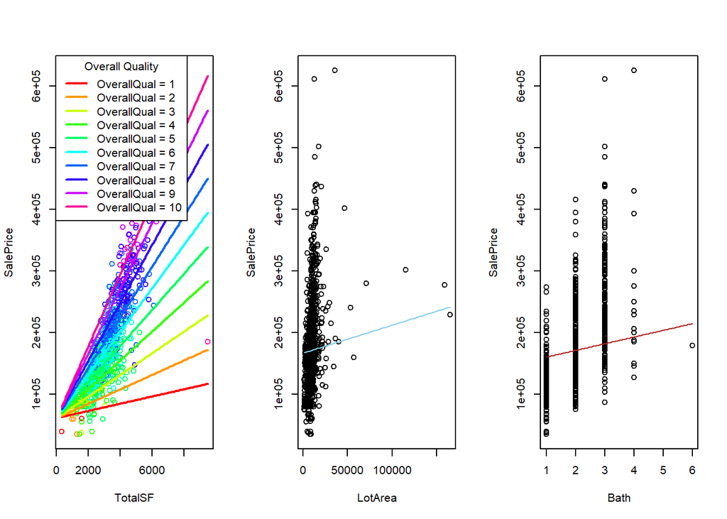

```r
b <- coef(Home)

mytrain <- mytrain %>%
  filter(!is.na(TotalSF))


par(mfrow=c(1,3))


### Each number being multiplied is a respective mean correlating to the variable it represents

  plot(SalePrice ~ TotalSF, data=mytrain, col=rainbow(10)[mytrain$OverallQual])
  colors = rainbow(10)
for (qual in 1:10) {
  curve(b[1] + b[2]*10516.83 + b[3]*2.048 + b[4]*x*qual,
        add=TRUE, col=colors[qual], lwd=2)
}
  legend("topleft", legend=paste("OverallQual =", 1:10), col=colors, lwd=2, title="Overall Quality")


  plot(SalePrice ~ LotArea, data=mytrain)
  curve(b[1] + b[2]*x + b[3]*2.048 + b[4]*3104.93*6.06, add=TRUE, col="skyblue")


  plot(SalePrice ~ Bath, data=mytrain)
  curve(b[1] + b[2]*10516.83 + b[3]*x + b[4]*3104.93*6.06, add=TRUE, col="firebrick")
```

### Interpretation

$$\hat{Y_i} = \beta_0 + \beta_1*LotArea + \beta_2*Bath +
\beta_3*TotalSF*OverallQual$$

```r
pander(summary(Home))
```

|  | Estimate | Std. Error | t value | Pr(>\|t\|) |
| --- | --- | --- | --- | --- |
| **(Intercept)** | 34463 | 2961 | 11.64 | 1.986e-29 |
| **LotArea** | 0.4526 | 0.1099 | 4.117 | 4.16e-05 |
| **Bath** | 10815 | 1618 | 6.684 | 3.885e-11 |
| **TotalSF:OverallQual** | 5.865 | 0.117 | 50.11 | 8.775e-274 |

Fitting linear model: SalePrice ~ TotalSF:OverallQual + LotArea + Bath

| Observations | Residual Std. Error | $R^2$ | Adjusted $R^2$ |
| --- | --- | --- | --- |
| 994 | 31114 | 0.8183 | 0.8178 |

Each of the terms is significant statistically, but a fair warning should go out that in all actuality, we may be overcompensating and our predictions could be incorrect. With a Residual Standard Error of 31114, it’s probable that a house’s SalePrice could land anywhere within 60000 of the prediction.

Firstly, our intercept is 34463, meaning if you have 0 Bath and 0 LotArea, you would estimate that a home would cost $34463. It’s not very sensible to buy a house without these things, and isn’t very realistic, but nonetheless this would be the correct interpretation based on our model.

Secondly, with how our model is organized, LotArea would also add to the base intercept. For each increase of LotArea of increment 1 square foot, you would estimate the cost of the home would go up $0.4526 from the standard $34463. Similarly, for every increase in Bath by increment 1, the cost of the home would go up $10815.

Finally, TotalSF:OverallQual is what controls the slope of the model. Because OverallQual is a value that ranges from 1 to 10, we have a couple interpretations to go over. If OverallQual were 1, then for every increase in TotalSF by 1 square foot, the price of the home would go up by $5.865. For each increase in 1 of OverallQual, the predicted price of the home would go up by another 5.865 per TotalSF (in other words, it would go up $11.73 per TotalSF if OverallQual were 2). If a home had an OverallQual of 10, the price of the home would go up $58.65 per TotalSF. In other words, the interaction between TotalSF and OverallQual determines how the effect of TotalSF on SalePrice changes as determined by the level or factor of OverallQual. TotalSF means a lot more if the OverallQual is higher.